# Hospital Spending

Nikesh,Pooja, Runhua

November 7, 2017

## Instructed by Andrea Wiggins

## R Script - 8086-002 - Data to Decisions

## The research questions are as follows:

1. Finding out on which claim type did all the hospital across USA has spent more and also for which period?
2. Finding the leading hospital in terms of spending based on the US zones and also finding the differences in spending by hospital on zone level?
3. Finding the amount spent in each state and grouping it under highest and lowest claim states?

## The content of this Assignment

1. Set the path of the data and load the file
2. Loading the library as needed
3. Subset and transform the data
4. Produce the summary table for the subsets
5. Process of plot using ggplot2 packages
6. Interpret and explain the figure.

## 1.1 Plot for which claim type did all the hospital across USA has spent more

### Setting the path to the folder of the date set, loading the data and checking the data

```r
setwd("D:/Graduate/3rd Sem(Fall)/8086-002 From Data To Decision/Team Project/R-Script")
HospitalSpending <- read.csv ("Medicare_Hospital_Spending_by_Claim_Cleaned.csv", stringsAsFactors = FALSE)
View(HospitalSpending) # view the data
```

### Loading the library

```r
library(doBy)
library(DT)
```

```r
library(xtable)
library(ggplot2)
library(reshape2)
library(GGally)
windowsFonts(Times=windowsFont("TT Times New Roman"))
```

### Subset and transform the data

```r
# select three columns of Claim_type, ASPE_Hospital, POS_Hospital for the folowing analyses
claimtype <- HospitalSpending[, c("Claim_type" , "ASPE_Hospital", "POS_Hospital")]

#change claim_type to full name for analyses
claimtype$Claim_type <- factor(claimtype$Claim_type, levels=c("Carrier","DME", "HHA", "Hospice", "Inpatient", "Outpatient", "SNF","Total"), labels=c("Carrier", "Durable Medical Equipment","Home Health Agency","Hospice","Inpatient","Outpatient", "Skilled Nursing Facility", "Total"))
```

### Produce the summary table for the subsets

```r
# summary table for the hospital spending nationally by claim types ($).
claimTable <- do.call(cbind.data.frame, aggregate(ASPE_Hospital ~ Claim_type, data=claimtype, FUN = function(x) {
  c("Number"=format(round(length(x), 0), nsmall = 0), M=format(round(mean(x), 2), nsmall = 2), min=min(x),max=max(x),
    se=format(round(sd(x)/sqrt(length(x)), 2), nsmall = 2),format(round(quantile(x,c(0.05, 0.25, 0.50, 0.75, 0.95)), 2), nsmall = 2), iqr=IQR(x)) })); names(claimTable) <- c("Claim Type", "Number", "Mean", "Minimum", "Maximum", "Se", "5% Quantile","25% Quantile","Median","75% Quantile", "95% Quantile", "IQR")
View(claimTable)

claimTablenew <- claimTable[1:7,c(1,3, 6)]
colnames(claimTablenew) <- c("claimType", "Mean", "SE")
str(claimTablenew)
```

```
## 'data.frame':    7 obs. of  3 variables:
##  $ claimType: Factor w/ 8 levels "Carrier","Durable Medical Equipment",..: 1 2 3 4 5 6 7
##  $ Mean     : Factor w/ 8 levels "1648.66","19042.89",..: 8 6 5 7 3 4 1
##  $ SE       : Factor w/ 8 levels "0.57","1.27",..: 6 1 7 2 5 4 3
```

```r
# change the factor to numeric
as.numeric.factor <- function(x) {as.numeric(levels(x))[x]}
claimTablenew$Mean <- as.numeric.factor(claimTablenew$Mean)
claimTablenew$SE <- as.numeric.factor(claimTablenew$SE)
str(claimTablenew)
```

```
## 'data.frame':    7 obs. of  3 variables:
##  $ claimType: Factor w/ 8 levels "Carrier","Durable Medical Equipment",..: 1 2 3 4 5 6 7
##  $ Mean     : num  933.1 43.4 394.1 84.2 3708.2 ...
##  $ SE       : num  5.11 0.57 5.61 1.27 40.04 ...
```

### Produce the bar chart with ggplot2

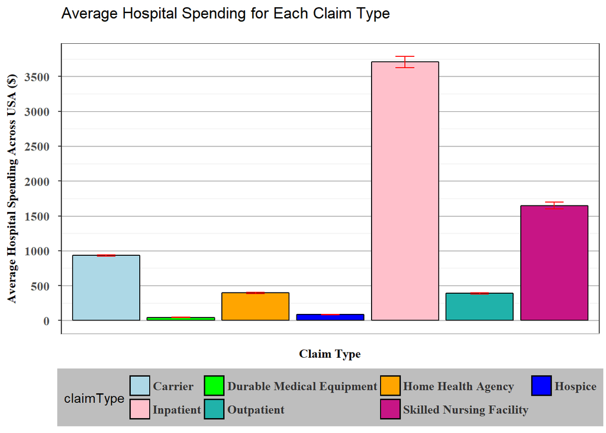

```r
ggplot(claimTablenew, aes(x=claimType, y=Mean, fill=claimType)) +
  geom_bar(position=position_dodge(.9), colour="black", stat="identity") +
  geom_errorbar(position=position_dodge(.9), color="red", width=.25, aes(ymin=claimTablenew$Mean - claimTablenew$SE*2, ymax=claimTablenew$Mean + claimTablenew$SE*2)) +
  scale_fill_manual(values=c("lightblue","green","orange","blue","pink","lightseagreen","mediumvioletred")) +
  labs(x = "Claim Type", y = "Average Hospital Spending Across USA ($)") +
  ggtitle("Average Hospital Spending for Each Claim Type\n") +
  theme_bw()+
  theme(panel.grid.major = element_line(color="gray50", size=0.2),
        panel.grid.major.x=element_blank(),
        axis.text.x=element_blank(),
        axis.ticks.x=element_blank(),
        legend.position=c("bottom"),
        legend.direction = "horizontal",
        legend.justification = 0.5,
        legend.key = element_rect(fill="black"), legend.background = element_rect(fill="gray"),
        legend.text =element_text(family="Times", size=10, face="bold", color="gray20"),
        axis.title.x=element_text(family="Times", color="black",face="bold", size=10, vjust=-1),
        axis.title.y=element_text(family="Times", color="black", face="bold", size=10, hjust=0.5),
        axis.text.y = element_text(family="Times", size =10, face="bold", margin = unit(c(t = 0, r = 2.5, b = 0, l = 0), "mm")),
        axis.line.x = element_line(color = "gray", size = 0.5),
        axis.line.y = element_line(color = "black", size = 0.5)) +
  guides(fill=guide_legend(nrow=2, byrow=TRUE))+
  scale_y_continuous(breaks=seq(0,20000, 500))
```

**Figure 1.** Average Hospital Spending for Each Claim Type Across USA in 2015.

## 1.2 Finding out on which period did all the hospital across USA has spent more

### Subset the data

```r
# select three columns of Period, ASPE_Hospital, POS_Hospital for the folowing analyses
head(HospitalSpending)
```

```
##                Hospital_Name Provider_ID State Claim_type    Period
## 1 ABBEVILLE GENERAL HOSPITAL      190034    LA        HHA BeforeIHA
## 2 ABBEVILLE GENERAL HOSPITAL      190034    LA    Hospice BeforeIHA
## 3 ABBEVILLE GENERAL HOSPITAL      190034    LA  Inpatient BeforeIHA
## 4 ABBEVILLE GENERAL HOSPITAL      190034    LA Outpatient BeforeIHA
## 5 ABBEVILLE GENERAL HOSPITAL      190034    LA        SNF BeforeIHA
## 6 ABBEVILLE GENERAL HOSPITAL      190034    LA        DME BeforeIHA
##   ASPE_Hospital ASPE_State ASPE_Nation POS_Hospital POS_State POS_Nation
## 1            28         20          14       0.0014    0.0009     0.0007
## 2             0          1           1       0.0000    0.0000     0.0000
## 3             0          5           5       0.0000    0.0003     0.0003
## 4            41        124         124       0.0021    0.0059     0.0061
## 5             3          3           2       0.0002    0.0001     0.0001
## 6             4         10           9       0.0002    0.0005     0.0004
##    X
## 1 NA
## 2 NA
## 3 NA
## 4 NA
## 5 NA
## 6 NA
```

```r
periodIHA <- HospitalSpending[, c("Period" , "ASPE_Hospital", "POS_Hospital")]
```

# Produce the summary table for the subsets

```r
# summary table for the hospital spending nationally by periods ($).
periodTable <- do.call(cbind.data.frame, aggregate(ASPE_Hospital ~ Period, data=periodIHA, FUN = function(x) {
  c("Number"=format(round(length(x), 0), nsmall = 0), M=format(round(mean(x), 2), nsmall = 2), min=min(x),max=max(x),     se=format(round(sd(x)/sqrt(length(x)), 2), nsmall = 2),format(round(quantile(x,c(0.05, 0.25, 0.50, 0.75, 0.95)), 2), nsmall = 2), iqr=IQR(x)) })); names(periodTable) <- c("Periods", "Number", "Mean", "Minimum", "Maximum", "SE", "5% Quantile","25% Quantile","Median","75% Quantile", "95% Quantile", "IQR")
View(periodTable)
periodTablenew <- periodTable[c(1,2,4), c(1,3, 6)]
colnames(periodTablenew) <- c("Periods", "Mean", "SE")
str(periodTablenew)
```

```
## 'data.frame':    3 obs. of  3 variables:
##  $ Periods: Factor w/ 4 levels "AfterIHA","BeforeIHA",..: 1 2 4
##  $ Mean   : Factor w/ 4 levels "1203.65","19042.89",..: 1 4 3
##  $ SE     : Factor w/ 4 levels "1.33","41.17",..: 4 1 2
```

```r
# change the factor to numeric
as.numeric.factor <- function(x) {as.numeric(levels(x))[x]}
periodTablenew$Mean <- as.numeric.factor(periodTablenew$Mean)
periodTablenew$SE <- as.numeric.factor(periodTablenew$SE)
str(periodTablenew)
```

```
## 'data.frame':    3 obs. of  3 variables:
##  $ Periods: Factor w/ 4 levels "AfterIHA","BeforeIHA",..: 1 2 4
##  $ Mean   : num  1203.7 96.4 3331
##  $ SE     : num  8.81 1.33 41.17
```

### Produce the bar chart with error bar by ggplot2

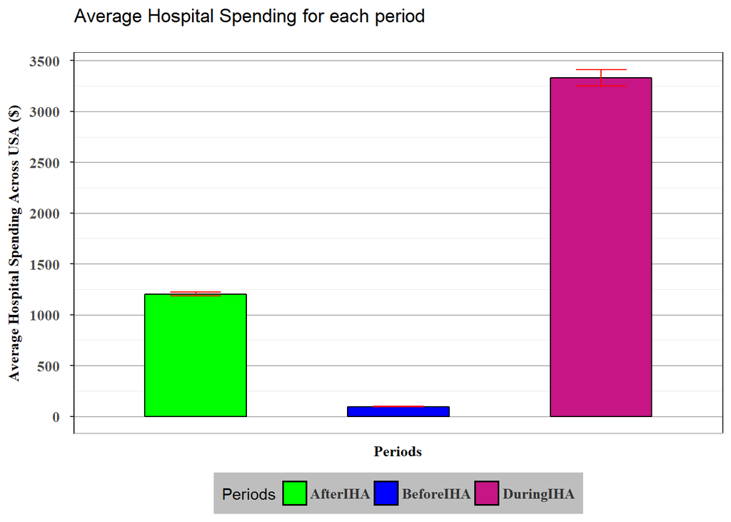

```r
ggplot(periodTablenew, aes(x=Periods, y=Mean, fill=Periods)) +
  geom_bar(position=position_dodge(.9), colour="black", stat="identity", width =0.5) +
  geom_errorbar(position=position_dodge(0.5), color="red", width=.25, aes(ymin=periodTablenew$Mean - periodTablenew$SE*2, ymax=periodTablenew$Mean + periodTablenew$SE*2)) +
  scale_fill_manual(values=c("green","blue","mediumvioletred")) +
  labs(x = "Periods", y = "Average Hospital Spending Across USA ($)") +
  ggtitle("Average Hospital Spending for each period\n") +
  theme_bw()+
  theme(panel.grid.major = element_line(color="gray50", size=0.2),
        panel.grid.major.x=element_blank(),
        axis.text.x=element_blank(),
        axis.ticks.x=element_blank(),
        legend.position=c("bottom"),
        legend.direction = "horizontal",
        legend.justification = 0.5,
        legend.key = element_rect(fill="black"), legend.background = element_rect(fill="gray"),
        legend.text =element_text(family="Times", size=10, face="bold", color="gray20"),
        axis.title.x=element_text(family="Times", color="black",face="bold", size=10, vjust=-1),
        axis.title.y=element_text(family="Times", color="black", face="bold", size=10, hjust=0.5),
        axis.text.y = element_text(family="Times", size =10, face="bold", margin = unit(c(t = 0, r = 2.5, b = 0, l = 0), "mm")),
        axis.line.x = element_line(color = "gray", size = 0.5),
        axis.line.y = element_line(color = "black", size = 0.5)) +
  scale_y_continuous(breaks=seq(0,20000, 500))
```

### Figure 2 Interpretation and explanation

Figure 2 represents the average hospital spending for each period such as 1 to 3 days Prior to Index Hospital Admission; 1 through 30 days After Discharge from Index Hospital Admission and During Index Hospital Admission based on the hospital spending data from the following [links](https://catalog.data.gov/dataset/medicare-hospital-spending-by-claim-61b57). From Figure 2, we found that the average hospital spending on during Index Hospital Admission is the most, then 1 through 30 days After Discharge from Index Hospital Admission, the least one is1 to 3 days Prior to Index Hospital Admission. This pattern may be due to multiple costs from doctor, nurse, equipment, room in hospital comparing to other periods, which are considerable expensive.

## 2 Finding the leading hospital in terms of spending based on the US zones and also finding the differences in spending by hospital on zone level?

## Region wise Plotting

### North East

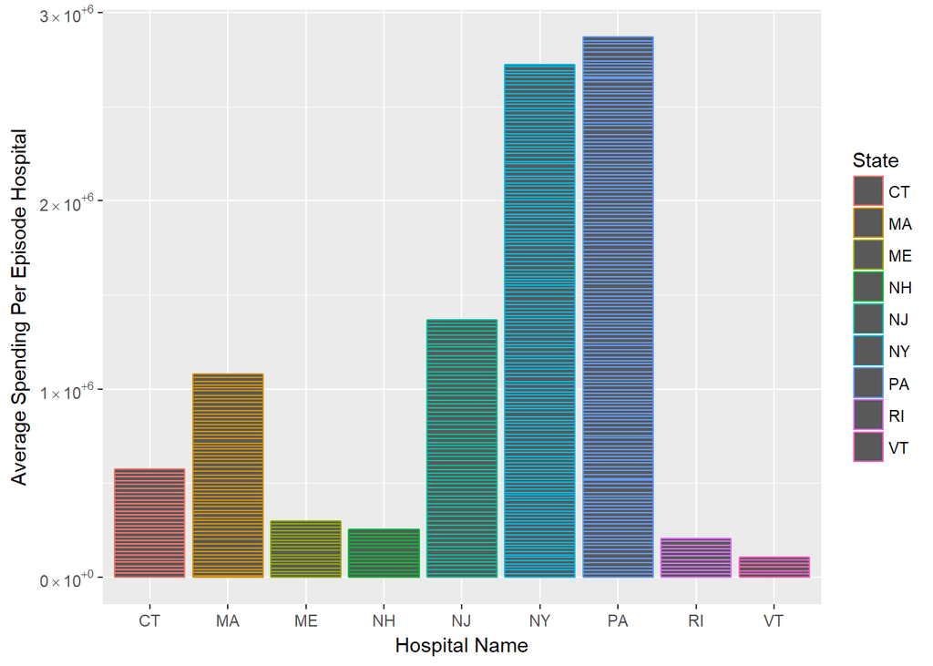

```
## $title
## [1] "Graph for highest spending per hospital in North East Region"
##
## $subtitle
## NULL
##
## attr(,"class")
## [1] "labels"
```

### Mid West

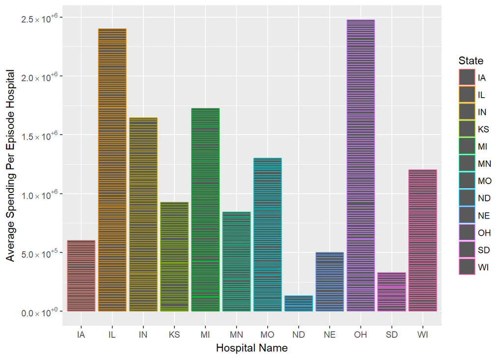

```
## $title
## [1] "Graph for highest spending per hospital in Midwest Region"
##
## $subtitle
## NULL
##
## attr(,"class")
## [1] "labels"
```

### South

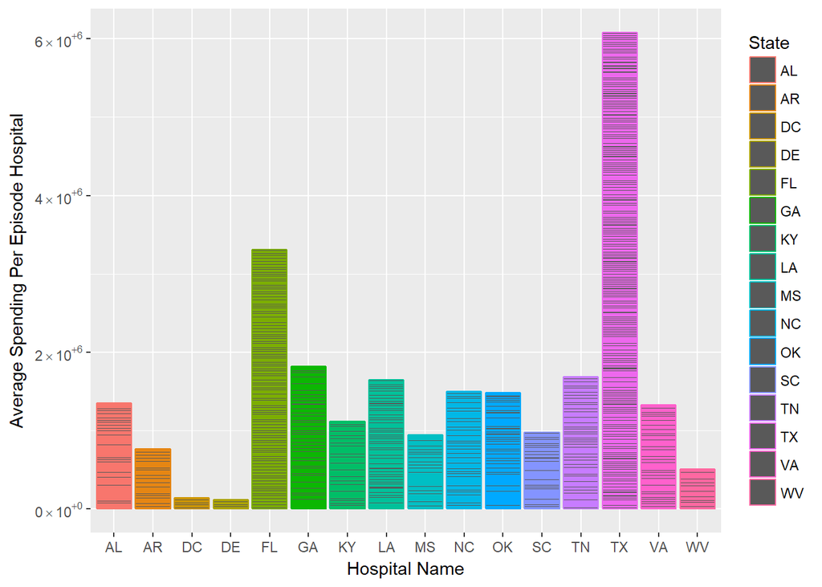

```
## $title
## [1] "Graph for highest spending per hospital in South Region"
##
## $subtitle
## NULL
##
## attr(,"class")
## [1] "labels"
```

### West

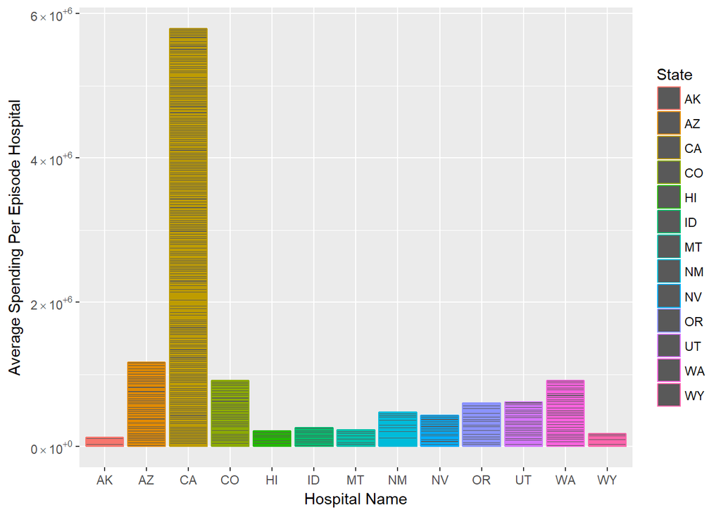

```
## $title
## [1] "Graph for highest spending per hospital in West Region"
##
## $subtitle
## NULL
##
## attr(,"class")
## [1] "labels"
```

## 2.2 Highest spending hospital in USA

### Finding the leading hospital in terms of spending based on the US zones and also finding the differences in spending by hospital on zone level?

### Graph for answering the above question

[figure not shown]

```r
library(ggmap)
write.csv(Region,"Region.csv")
r <- read.csv("Region.csv")
geocodes <- geocode(as.character(r$State))
r1 <- data.frame(r[,1:7],geocodes)
head(r1)
```

```
##       X                           Hospital_Name State ASPE_Hospital
## 1 17114                HACKENSACK UNIVERSITY MC    NJ         25559
## 2 22440                 KINGS DAUGHTERS MC OHIO    OH         35735
## 3 14694 FOUNDATION SURGICAL HOSPITAL OF EL PASO    TX         41469
## 4 24518                         LOS ANGELES CMH    CA         29502
##       Region             Zone
## 1 North East NJ \n North East
## 2   Mid West   OH \n Mid West
## 3      South      TX \n South
## 4       West       CA \n West
##                                                 Hospital        lon
## 1           HACKENSACK UNIVERSITY MC \n NJ \n North East  -74.40566
## 2              KINGS DAUGHTERS MC OHIO \n OH \n Mid West  -82.90712
## 3 FOUNDATION SURGICAL HOSPITAL OF EL PASO \n TX \n South  -99.90181
## 4                          LOS ANGELES CMH \n CA \n West -119.41793
##        lat
## 1 40.05832
## 2 40.41729
## 3 31.96860
## 4 36.77826
```

## Interpretation and Explanation

Details about all the hospitals in USA who spend on patients over various claim types per year is present in particular dataset. Based on regions, We wanted to find the hospitals who spent more money on patients.

From the graph we can infer that, **Foundation Surgical hospital from Texas** has spent more money on its patients in South region. Similarly **Hackensack University medical center**,**Kings daughters medical center** and **Los Angeles** hospitals have spent good amount on patients in their regions.

If we compare between the highest spending hospital from the graph then **Foundation Surgical hospital from Texas** has spent more when compared to **Hackensack University medical center**.

# Same result represented in different way using MAP

[figure not shown]

```r
summary(Region)
```

```
##                                  Hospital_Name     State   ASPE_Hospital
##  FOUNDATION SURGICAL HOSPITAL OF EL PASO:1     CA     :1   Min.   :25559
##  HACKENSACK UNIVERSITY MC               :1     NJ     :1   1st Qu.:28516
##  KINGS DAUGHTERS MC OHIO                :1     OH     :1   Median :32619
##  LOS ANGELES CMH                        :1     TX     :1   Mean   :33066
##                                         :0            :0   3rd Qu.:37169
##  ABBEVILLE GENERAL HOSPITAL             :0     AK     :0   Max.   :41469
##  (Other)                                :0     (Other):0
##     Region              Zone             Hospital
##  Length:4           Length:4           Length:4
##  Class :character   Class :character   Class :character
##  Mode  :character   Mode  :character   Mode  :character
##
##
##
##
```

3. Finding the amount spent in each state and grouping it under highest and lowest claim states?

# Finding the amount spent in each state and grouping it under highest and lowest claim states

```r
## North East Region
StateSpending_northeast <- subset(StateSpending, State %in% c("CT", "ME", "MA", "NH", "RI", "VT", "NJ", "PA", "NY"))

## Midwest Region
StateSpending_midwest <- subset(StateSpending, State %in% c("IN", "IL", "MI", "OH", "WI", "IA", "KS", "MN", "MO", "NE", "ND", "SD"))

## South Region

StateSpending_south <- subset(StateSpending, State %in% c("DE", "DC", "FL", "GA", "MD", "NC", "SC", "VA", "WV", "AL", "KY", "MS", "TN", "AR", "LA", "OK", "TX"))

## West Region

StateSpending_west <- subset(StateSpending, State %in% c("AZ", "CO", "ID", "NM", "MT", "UT", "NV", "WY", "AK", "CA", "HI", "OR", "WA"))
```

## Statewise Plotting of the Spending

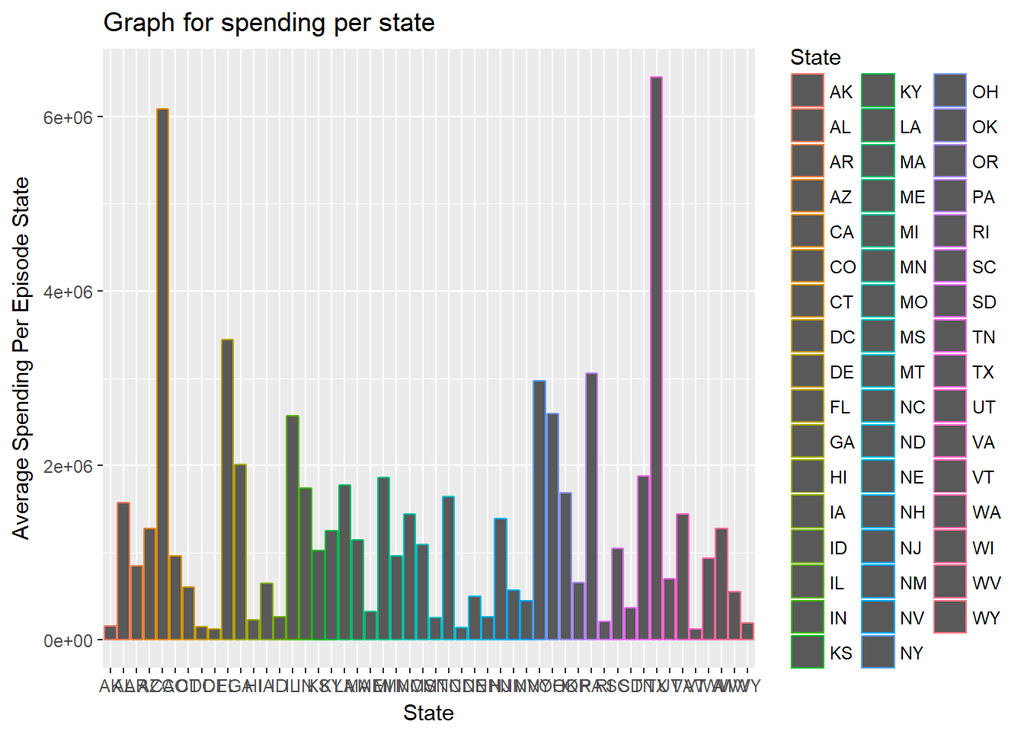

## Reploting the graph after changing the expontential values to numbers

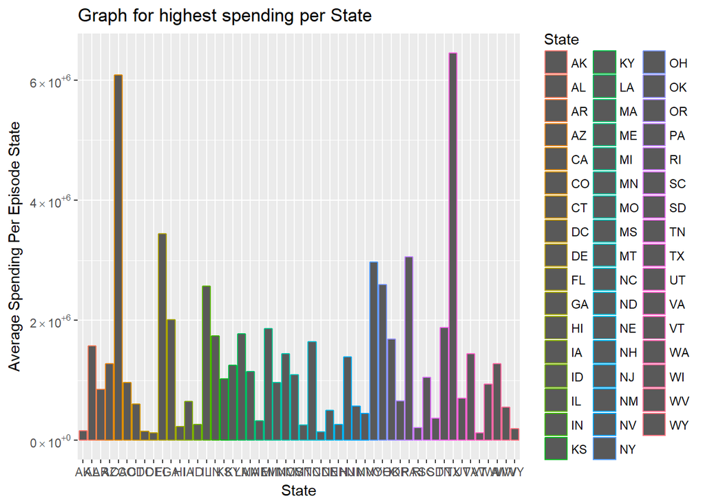

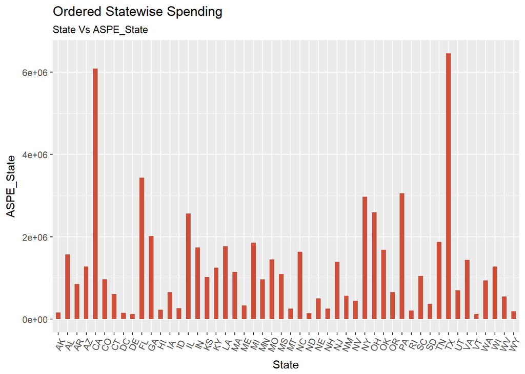

## Reploting the graph after changing the expontential to numbers

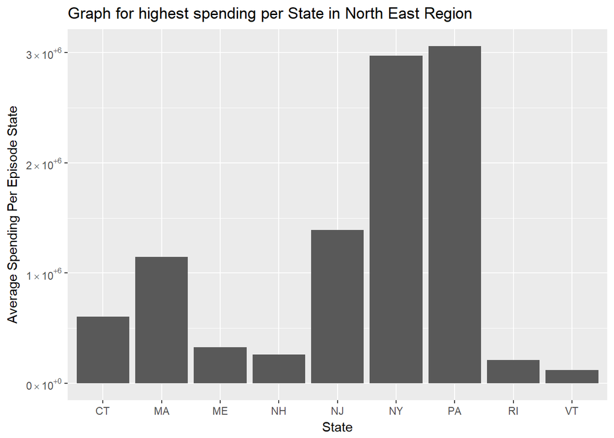

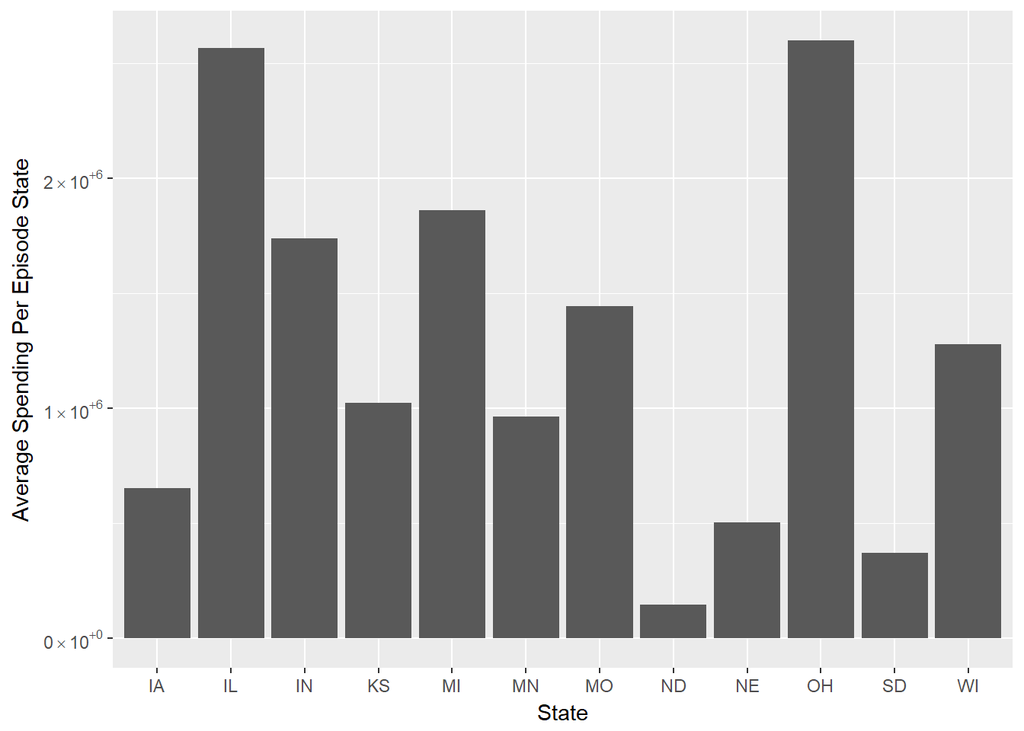

```
## $title
## [1] "Graph for highest spending per State in Midwest Region"
##
## $subtitle
## NULL
##
## attr(,"class")
## [1] "labels"
```

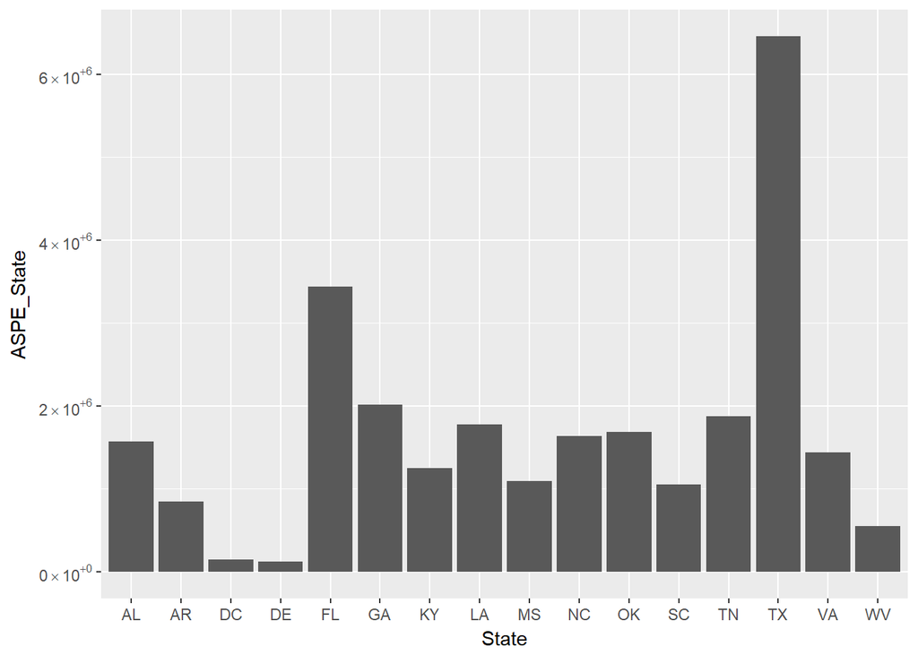

```
## $title
## [1] "Graph for highest spending per State in South Region"
##
## $subtitle
## NULL
##
## attr(,"class")
## [1] "labels"
```

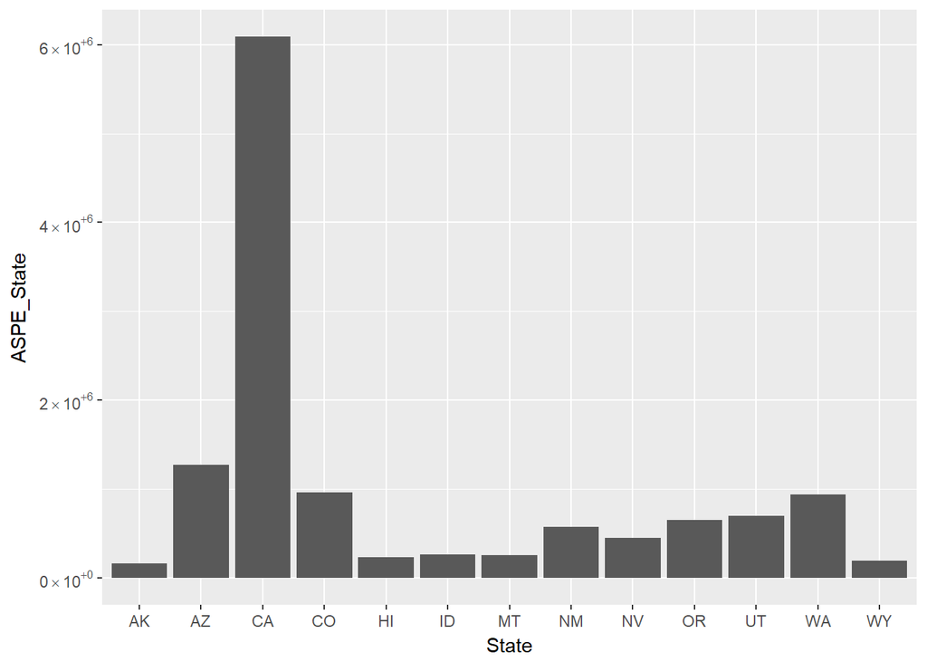

```
## $title
## [1] "Graph for highest spending per State in West Region"
##
## $subtitle
## NULL
##
## attr(,"class")
## [1] "labels"
```